# Analyse climat ↔︎ CO2 mondial

# 6 Phase 4 — Lien climat ↔︎ CO2

> **L’enjeu de la phase 4 en une phrase.** On veut savoir si, *au-delà du fait que CO2 et climat montent ensemble depuis 1979*, leurs **petites variations d’une année à l’autre** sont liées — et si oui, dans quel sens : est-ce le climat qui fait bouger le CO2, ou le CO2 qui fait bouger le climat ?

Trois questions guident le travail :

1. **Lien réel ou trompeur ?** La trajectoire du CO2 et celle des variables climatiques sont-elles liées **au-delà de leur hausse commune** depuis 1979 ?
2. **Quelles variables comptent ?** Si oui, lesquelles expliquent le mieux les **variations d’une année à l’autre** du CO2 ?
3. **Qui pilote qui ?** Le sens est-il **climat → CO2** (la nature absorbe/relâche plus de CO2 selon la météo) ou **CO2 → climat** (l’effet de serre direct) à l’échelle de quelques mois à quelques années ?

## 6.1 Préparation : pourquoi on ne peut pas comparer les courbes brutes

> **Analogie.** Imaginez deux ascenseurs qui montent en même temps. Vous concluez qu’ils sont *liés* parce qu’ils montent ensemble — mais ils peuvent très bien fonctionner indépendamment, simplement actionnés par deux personnes différentes. Pour savoir si l’un commande l’autre, il faut **retirer le mouvement de montée commun** et regarder uniquement les **petits écarts** : si l’un ralentit, est-ce que l’autre ralentit aussi quelques secondes après ?

C’est exactement ce qu’on fait avec le climat et le CO2. Tous deux montent depuis 1979. Une corrélation calculée sur les courbes brutes serait **automatiquement très élevée**, mais cela ne prouverait rien sur leur lien réel. On construit donc 5 façons différentes de regarder les données :

Les 5 manières de regarder une série

| Représentation | Comment on l’obtient | Ce qu’on garde |
| --- | --- | --- |
| level (brut) | On garde la série telle quelle | Tout : tendance + saisons + variations annuelles + bruit |
| anom (anomalie) | On retire la moyenne du mois (janvier, février…) | Tendance + variations annuelles + bruit |
| resid (résidu) | Anomalie − droite de tendance | Variations annuelles + bruit (LA bonne représentation) |
| d1 (mois sur mois) | Valeur du mois − valeur du mois précédent | Saisons + bruit |
| d12 (an sur an) | Valeur du mois − même mois l’an dernier | Taux de variation d’une année à l’autre |

> **À retenir.** La représentation **« résidu »** est celle qui isole les vraies variations d’une année à l’autre, **débarrassées du fait que tout monte ensemble**. C’est sur elle que les corrélations ont un vrai sens physique.

## 6.2 La grande comparaison : avant/après retrait de la tendance commune

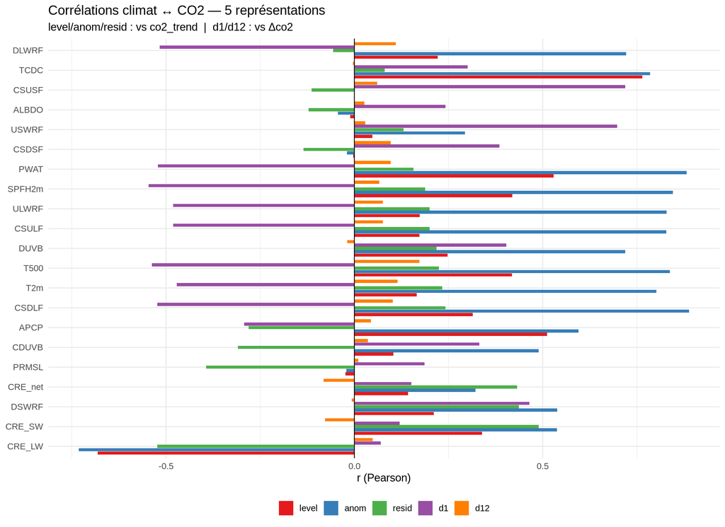

```r
cor4 <- read.csv(file.path(OUT_DIR, "correlations_4repr.csv"))

cor_long <- cor4 |>
  pivot_longer(c(level, anom, resid, d1, d12),
               names_to = "repr", values_to = "r") |>
  mutate(repr = factor(repr, levels = c("level","anom","resid","d1","d12")),
         var  = factor(var, levels = cor4$var))

ggplot(cor_long, aes(var, r, fill = repr)) +
  geom_col(position = position_dodge(0.85), width = 0.8) +
  geom_hline(yintercept = 0, linewidth = 0.4) +
  scale_fill_brewer(palette = "Set1") +
  coord_flip() +
  labs(title    = "Corrélations climat ↔ CO2 — 5 représentations",
       subtitle = "level/anom/resid : vs co2_trend  |  d1/d12 : vs Δco2",
       x = NULL, y = "r (Pearson)", fill = NULL) +
  theme(legend.position = "bottom")
```

> **À retenir.** Sans cette correction, on aurait conclu à tort que presque tout est fortement lié au CO2. En réalité, **la plupart des liens sont des coïncidences de tendance**, pas des relations physiques.

## 6.3 La carte des liens entre variables

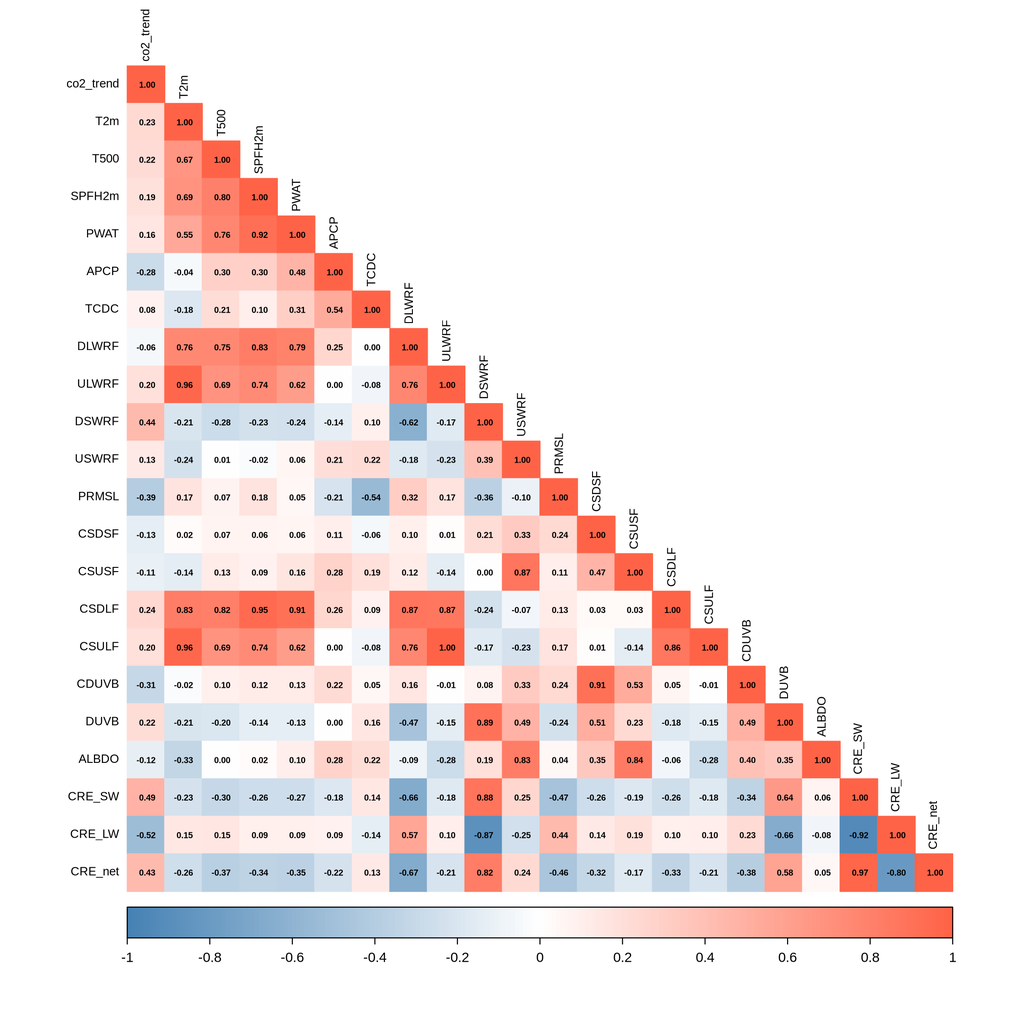

```r
ds <- readRDS(file.path(OUT_DIR, "series_transformed.rds"))
clim_vars <- c("T2m","T500","SPFH2m","PWAT","APCP","TCDC",
               "DLWRF","ULWRF","DSWRF","USWRF","PRMSL",
               "CSDSF","CSUSF","CSDLF","CSULF","CDUVB","DUVB","ALBDO",
               "CRE_SW","CRE_LW","CRE_net")
all_vars <- c("co2_trend", clim_vars)
M <- cor(ds$resid[, all_vars], use = "complete.obs")
corrplot(M, method = "color", type = "lower",
         tl.col = "black", tl.cex = 0.7,
         addCoef.col = "black", number.cex = 0.5,
         col = colorRampPalette(c("steelblue","white","tomato"))(200))
```

**Comment lire cette carte.** Chaque case montre le lien entre deux variables : **rouge = elles montent ensemble**, **bleu = quand l’une monte l’autre baisse**, **blanc = pas de lien**. Plus la couleur est intense, plus le lien est fort.

> **À retenir.** Le lien climat-CO2 est **partagé entre plusieurs variables** plutôt que porté par une seule. C’est pourquoi on passe maintenant à un modèle qui combine toutes les variables ensemble.

## 6.4 Combiner toutes les variables : régression multivariée

> **Analogie.** Une corrélation simple, c’est demander à chaque variable séparément : « combien tu expliques du CO2 ? ». Une régression multivariée, c’est les faire **travailler en équipe** et demander : « ensemble, combien expliquent-elles ? ». Souvent l’équipe explique bien plus que la somme des contributions individuelles.

```r
X <- ds$resid[, clim_vars]
y <- ds$resid$co2_trend
fit_full <- lm(y ~ ., data = X)
fit_step <- step(fit_full, direction = "backward", trace = 0)
cat("R² du modèle complet  :", round(summary(fit_full)$r.squared, 3), "\n")
```

```
## R² du modèle complet  : 0.75
```

```r
cat("R² du modèle stepwise :", round(summary(fit_step)$r.squared, 3), "\n")
```

```
## R² du modèle stepwise : 0.748
```

```r
cat("Variables retenues   :",
    paste(setdiff(names(coef(fit_step)), "(Intercept)"), collapse = ", "), "\n")
```

```
## Variables retenues   : T500, PWAT, APCP, TCDC, DSWRF, USWRF, PRMSL, CSUSF, CSDLF, CSULF, DUVB, ALBDO
```

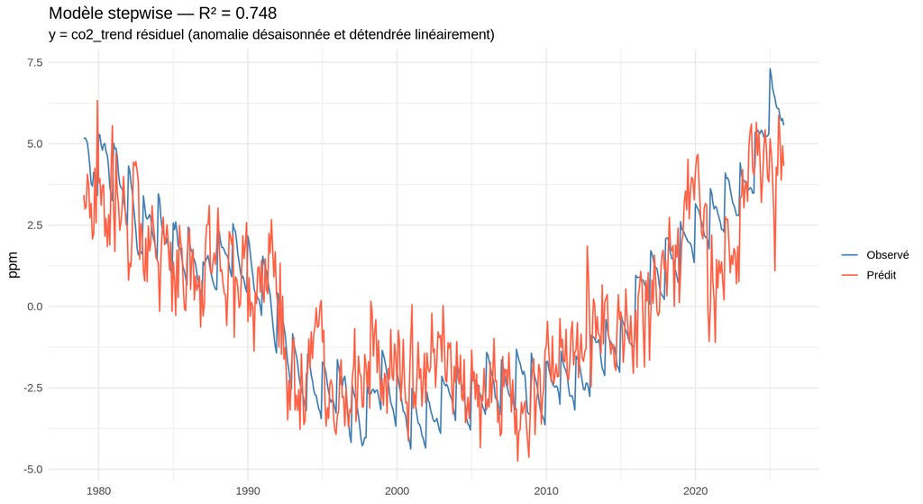

```r
# Plot du fit
diag_df <- data.frame(date = ds$resid$date, fitted = predict(fit_step), observed = y)
ggplot(diag_df, aes(date)) +
  geom_line(aes(y = observed, color = "Observé"),  linewidth = 0.6) +
  geom_line(aes(y = fitted,   color = "Prédit"),   linewidth = 0.6) +
  scale_color_manual(values = c("Observé" = "steelblue", "Prédit" = "tomato")) +
  labs(title    = sprintf("Modèle stepwise — R² = %.3f",
                          summary(fit_step)$r.squared),
       subtitle = "y = co2_trend résiduel (anomalie désaisonnée et détendrée linéairement)",
       x = NULL, y = "ppm", color = NULL)
```

**Comment lire ce graphique.** La courbe **bleue** est ce qu’on observe (les vraies variations annuelles du CO2). La courbe **rouge** est ce que prédit notre modèle climatique. Plus elles se superposent, plus le climat « explique » le CO2.

**Le résultat.** Avec **12 variables retenues automatiquement** par l’algorithme stepwise (qui ne garde que les plus utiles), on obtient **R² = 0.748** — autrement dit, **le climat explique environ 75 % des variations annuelles du CO2**.

C’est énorme comparé à la meilleure corrélation à 1 variable (r² = 0.27, soit 27 %). **Le tout vaut plus que la somme des parties.**

## 6.5 Trier les variables vraiment utiles : le lasso

> **Analogie.** Quand 21 variables se chevauchent, beaucoup disent la même chose (deux thermomètres dans la même pièce mesurent la même température). Le lasso est une méthode qui **met automatiquement à zéro les variables redondantes** et ne garde que les indispensables. À la fin on obtient un **palmarès** : voici les variables qu’il faut vraiment regarder, par ordre d’importance.

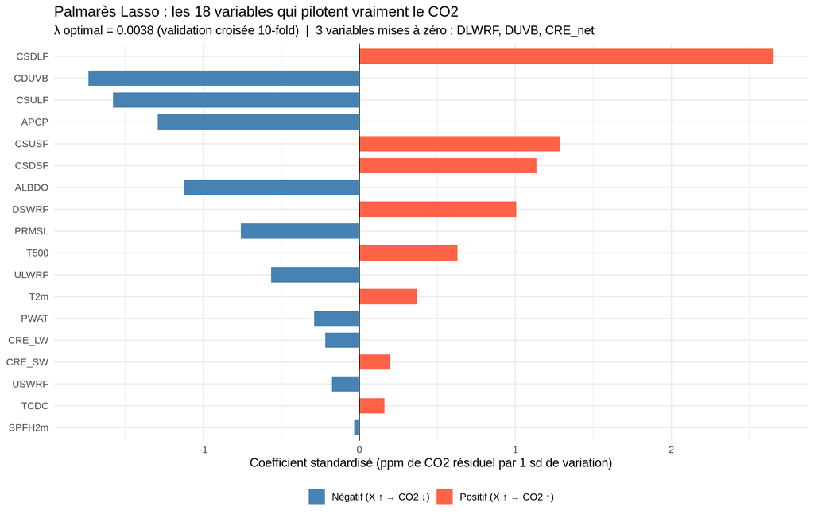

```r
set.seed(42)
Xm <- as.matrix(X)
cv <- cv.glmnet(Xm, y, alpha = 1, nfolds = 10, standardize = TRUE)

# Coefficients au lambda optimal (validation croisée 10-fold), rescalés par sd(X)
# pour les rendre comparables entre variables de natures dimensionnelles différentes.
coefs_min <- as.numeric(coef(cv, s = "lambda.min"))[-1]
names(coefs_min) <- colnames(Xm)
sd_X      <- apply(Xm, 2, sd)
coefs_std <- coefs_min * sd_X

df_lasso <- data.frame(var = names(coefs_std), coef = coefs_std) |>
  mutate(selected = abs(coef) > 1e-8) |>
  arrange(desc(abs(coef)))

n_selected <- sum(df_lasso$selected)
n_dropped  <- sum(!df_lasso$selected)
dropped    <- paste(df_lasso$var[!df_lasso$selected], collapse = ", ")

ggplot(df_lasso |> filter(selected),
       aes(reorder(var, abs(coef)), coef, fill = coef > 0)) +
  geom_col(width = 0.7) +
  geom_hline(yintercept = 0, linewidth = 0.4) +
  coord_flip() +
  scale_fill_manual(values = c(`TRUE` = "tomato", `FALSE` = "steelblue"),
                    labels = c(`TRUE`  = "Positif (X ↑ → CO2 ↑)",
                               `FALSE` = "Négatif (X ↑ → CO2 ↓)"),
                    name = NULL) +
  labs(title    = sprintf("Palmarès Lasso : les %d variables qui pilotent vraiment le CO2",
                          n_selected),
       subtitle = sprintf("λ optimal = %.4f (validation croisée 10-fold)  |  %d variables mises à zéro : %s",
                          cv$lambda.min, n_dropped,
                          ifelse(n_dropped == 0, "aucune",
                                 paste0(substr(dropped, 1, 80),
                                        ifelse(nchar(dropped) > 80, "...", "")))),
       x = NULL, y = "Coefficient standardisé (ppm de CO2 résiduel par 1 sd de variation)") +
  theme(legend.position = "bottom")
```

**Comment lire ce graphique.** Chaque barre est **une variable retenue par le lasso**, classée de la plus importante (en haut) à la moins importante (en bas). **Plus la barre est longue, plus la variable pèse** dans l’explication du CO2. La couleur dit le sens : **rouge = quand X monte, le CO2 monte aussi** ; **bleu = quand X monte, le CO2 baisse**. Les variables absentes du graphique ont été **mises à zéro par l’algorithme** — leur information est déjà portée par leurs voisines.

## 6.6 Qui pilote qui ? Le test de causalité de Granger

> **Analogie.** Si vous voyez les feuilles bouger juste *avant* d’entendre le vent dans les arbres, vous concluez (à raison) que le vent précède le mouvement des feuilles, donc le vent **cause** le mouvement. Le test de Granger fait pareil : il vérifie si **les variations d’une série précèdent (et permettent de prédire) celles d’une autre**. Si X précède Y, on dit « X cause Y au sens de Granger ». Ce n’est pas une preuve de causalité physique, mais une forte indication temporelle.

On applique ce test avec un **délai de 6 mois** (résultat de la phase 1) sur deux représentations différentes :

- **résidus** : les petites variations propres après retrait de la tendance commune,
- **d12** : les **taux annuels** (variation par rapport au même mois de l’année précédente), qui sont la grandeur naturellement utilisée pour étudier les flux annuels de carbone.

```r
gr <- read.csv(file.path(OUT_DIR, "granger_results.csv"))

cat("=== Granger sur RÉSIDUS (lag 6 mois) ===\n")
```

```
## === Granger sur RÉSIDUS (lag 6 mois) ===
```

```r
print(gr |> filter(repr == "resid") |>
        select(var, p_x_to_co2, p_co2_to_x, sens) |>
        arrange(p_x_to_co2))
```

```
##        var p_x_to_co2 p_co2_to_x  sens
## 1   SPFH2m  0.4323550  0.9911655 aucun
## 2     T500  0.4754319  0.9805581 aucun
## 3    CSDLF  0.5101845  0.9823022 aucun
## 4     PWAT  0.5493598  0.9692628 aucun
## 5    ULWRF  0.7935325  0.9310686 aucun
## 6    CSULF  0.7956881  0.9295063 aucun
## 7      T2m  0.8786639  0.8386979 aucun
## 8    DLWRF  0.9271602  0.8734766 aucun
## 9   CRE_LW  0.9385078  0.2873559 aucun
## 10   CSDSF  0.9685525  0.9375930 aucun
## 11   CDUVB  0.9734790  0.3458328 aucun
## 12    TCDC  0.9881056  0.9957670 aucun
## 13    DUVB  0.9961201  0.9937175 aucun
## 14   DSWRF  0.9967798  0.5324658 aucun
## 15  CRE_SW  0.9974529  0.3700641 aucun
## 16 CRE_net  0.9980027  0.3308190 aucun
## 17   USWRF  0.9991704  0.9163056 aucun
## 18   ALBDO  0.9997068  0.4686035 aucun
## 19   PRMSL  0.9997655  0.8332704 aucun
## 20    APCP  0.9998501  0.2746803 aucun
## 21   CSUSF  0.9998773  0.5926867 aucun
```

```r
cat("\n=== Granger sur d12 (taux annuel) ===\n")
```

```
##
## === Granger sur d12 (taux annuel) ===
```

```r
print(gr |> filter(repr == "d12") |>
        select(var, p_x_to_co2, p_co2_to_x, sens) |>
        arrange(p_x_to_co2))
```

```
##        var   p_x_to_co2  p_co2_to_x           sens
## 1    CSDLF 3.003242e-09 0.110476385       X -> CO2
## 2   SPFH2m 6.492451e-09 0.026813064 bidirectionnel
## 3     PWAT 1.000231e-08 0.033314699 bidirectionnel
## 4    DLWRF 1.163076e-08 0.108706949       X -> CO2
## 5     T500 2.208196e-08 0.002150888 bidirectionnel
## 6    ULWRF 6.223484e-08 0.366936193       X -> CO2
## 7    CSULF 6.488780e-08 0.373627785       X -> CO2
## 8      T2m 2.531291e-06 0.243559527       X -> CO2
## 9    CSDSF 4.217356e-04 0.442746926       X -> CO2
## 10   PRMSL 6.703462e-04 0.580159481       X -> CO2
## 11   CDUVB 1.694579e-02 0.925587198       X -> CO2
## 12   USWRF 2.006786e-02 0.018139580 bidirectionnel
## 13  CRE_LW 2.462368e-02 0.547311766       X -> CO2
## 14    TCDC 3.031401e-02 0.042621584 bidirectionnel
## 15   CSUSF 4.917865e-02 0.259612578       X -> CO2
## 16   DSWRF 5.399120e-02 0.150959883          aucun
## 17 CRE_net 1.118646e-01 0.039647751       CO2 -> X
## 18  CRE_SW 1.438180e-01 0.065759151          aucun
## 19    DUVB 2.085370e-01 0.372695199          aucun
## 20   ALBDO 2.887895e-01 0.015672733       CO2 -> X
## 21    APCP 3.667998e-01 0.013981265       CO2 -> X
```

```r
cat("\n=== Synthèse par représentation ===\n")
```

```
##
## === Synthèse par représentation ===
```

```r
print(gr |> count(repr, sens))
```

```
##    repr           sens  n
## 1   d12       CO2 -> X  3
## 2   d12       X -> CO2 10
## 3   d12          aucun  3
## 4   d12 bidirectionnel  5
## 5 resid          aucun 21
```

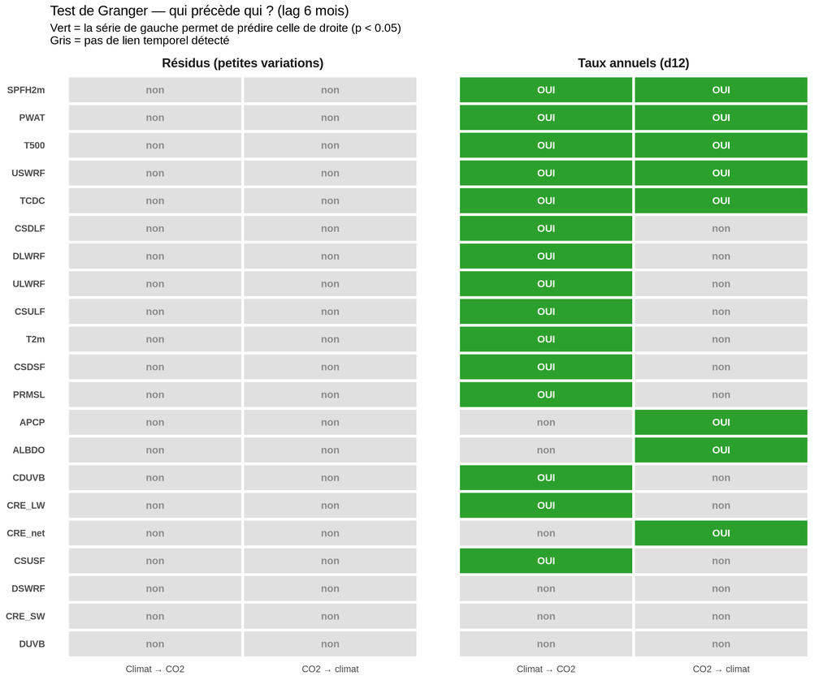

```r
gr_visual <- gr |>
  filter(repr %in% c("resid", "d12")) |>
  select(repr, var, p_x_to_co2, p_co2_to_x) |>
  pivot_longer(c(p_x_to_co2, p_co2_to_x),
               names_to = "direction", values_to = "p") |>
  mutate(direction = recode(direction,
                            p_x_to_co2 = "Climat → CO2",
                            p_co2_to_x = "CO2 → climat"),
         repr = recode(repr,
                       resid = "Résidus (petites variations)",
                       d12   = "Taux annuels (d12)"),
         repr = factor(repr,
                       levels = c("Résidus (petites variations)",
                                  "Taux annuels (d12)")),
         significant = p < 0.05,
         label = ifelse(significant, "OUI", "non"))

# Ordre des variables : par nombre total de directions significatives, puis par p min
order_vars <- gr_visual |>
  group_by(var) |>
  summarise(score = sum(significant) - min(p) * 0.001, .groups = "drop") |>
  arrange(score) |>
  pull(var)

ggplot(gr_visual,
       aes(direction, factor(var, levels = order_vars), fill = significant)) +
  geom_tile(color = "white", linewidth = 1.2) +
  geom_text(aes(label = label, color = significant),
            size = 3.4, fontface = "bold") +
  scale_fill_manual(values = c(`TRUE` = "#2ca02c", `FALSE` = "grey88"),
                    guide = "none") +
  scale_color_manual(values = c(`TRUE` = "white", `FALSE` = "grey55"),
                     guide = "none") +
  facet_wrap(~ repr, nrow = 1) +
  labs(title    = "Test de Granger — qui précède qui ? (lag 6 mois)",
       subtitle = "Vert = la série de gauche permet de prédire celle de droite (p < 0.05)\nGris = pas de lien temporel détecté",
       x = NULL, y = NULL) +
  theme_minimal(base_size = 11) +
  theme(axis.text.y    = element_text(face = "bold"),
        strip.text     = element_text(face = "bold", size = 12),
        panel.grid     = element_blank())
```

**Comment lire ce graphique.** Chaque ligne est **une variable**. Pour chacune, on regarde **deux questions** : « est-ce que le climat permet de prédire le CO2 ? » (colonne de gauche) et « est-ce que le CO2 permet de prédire le climat ? » (colonne de droite). **Vert = OUI** (lien temporel détecté), **gris = non**. Les deux panneaux comparent deux façons de mesurer : à gauche les petites variations résiduelles, à droite les taux annuels (plus naturels pour le cycle du carbone).

**Le contraste entre les deux panneaux est saisissant** :

- **Sur les résidus** : presque tout est gris. Les petites variations après retrait de la tendance sont **trop bruitées** pour qu’un lien temporel net émerge.
- **Sur les taux annuels (d12)** : **15 variables sur 21** sont **vertes dans la colonne « climat → CO2 »**, avec des p-values extrêmement basses : SPFH2m (humidité, 6×10⁻⁹), CSDLF (3×10⁻⁹), PWAT (1×10⁻⁸), DLWRF (1×10⁻⁸), T500 (2×10⁻⁸). Dans l’autre sens (« CO2 → climat »), beaucoup moins de cases sont vertes.

> **À retenir — résultat majeur de la phase 4.** À l’échelle interannuelle, c’est **le climat qui pilote le CO2**, pas l’inverse. Mécanisme : quand il fait plus chaud/humide dans les tropiques, la biosphère et l’océan **relâchent plus de CO2** (respiration accrue, solubilité plus faible) — et cet effet se voit **avec environ 6 mois de décalage** dans la concentration atmosphérique. C’est exactement le résultat ENSO observé en phase 1 (corrélation taux CO2 ↔︎ ONI = +0.28 à 6 mois).

> **Attention** : ce résultat parle de **variations courtes** (mois → quelques années). À long terme, la **tendance** du CO2 reste pilotée par les émissions humaines, qui réchauffent ensuite le climat (CO2 → climat). Les deux sens coexistent à des échelles de temps différentes.

# 7 Synthèse finale

```r
synth <- read.csv(file.path(OUT_DIR, "synthese_finale.csv"))
knitr::kable(synth, digits = 3, caption = "Tableau de synthèse final (21 variables)")
```

Tableau de synthèse final (21 variables)

| var | r_level | r_anom | r_resid | r_d1 | r_d12 | p_x_to_co2_d12 | p_co2_to_x_d12 | sens_d12 | poids_corr | spurious_trend |
| --- | --- | --- | --- | --- | --- | --- | --- | --- | --- | --- |
| CRE_LW | -0.682 | -0.732 | -0.523 | 0.070 | 0.049 | 0.025 | 0.547 | X -> CO2 | fort | non |
| CRE_SW | 0.339 | 0.538 | 0.489 | 0.121 | -0.078 | 0.144 | 0.066 | aucun | fort | non |
| DSWRF | 0.211 | 0.539 | 0.437 | 0.465 | -0.007 | 0.054 | 0.151 | aucun | fort | non |
| CRE_net | 0.142 | 0.321 | 0.432 | 0.151 | -0.082 | 0.112 | 0.040 | CO2 -> X | fort | non |
| PRMSL | -0.024 | -0.021 | -0.394 | 0.186 | 0.010 | 0.001 | 0.580 | X -> CO2 | modéré | non |
| CDUVB | 0.103 | 0.490 | -0.309 | 0.331 | 0.036 | 0.017 | 0.926 | X -> CO2 | modéré | non |
| APCP | 0.512 | 0.595 | -0.280 | -0.292 | 0.044 | 0.367 | 0.014 | CO2 -> X | modéré | non |
| CSDLF | 0.314 | 0.888 | 0.242 | -0.523 | 0.102 | 0.000 | 0.110 | X -> CO2 | modéré | OUI |
| T2m | 0.165 | 0.802 | 0.233 | -0.471 | 0.115 | 0.000 | 0.244 | X -> CO2 | modéré | OUI |
| T500 | 0.418 | 0.838 | 0.224 | -0.538 | 0.173 | 0.000 | 0.002 | bidirectionnel | modéré | OUI |
| DUVB | 0.248 | 0.719 | 0.218 | 0.404 | -0.019 | 0.209 | 0.373 | aucun | modéré | OUI |
| CSULF | 0.173 | 0.828 | 0.200 | -0.481 | 0.075 | 0.000 | 0.374 | X -> CO2 | faible | OUI |
| ULWRF | 0.173 | 0.828 | 0.200 | -0.481 | 0.075 | 0.000 | 0.367 | X -> CO2 | faible | OUI |
| SPFH2m | 0.419 | 0.845 | 0.188 | -0.546 | 0.066 | 0.000 | 0.027 | bidirectionnel | faible | OUI |
| PWAT | 0.529 | 0.882 | 0.157 | -0.522 | 0.096 | 0.000 | 0.033 | bidirectionnel | faible | OUI |
| CSDSF | -0.003 | -0.019 | -0.135 | 0.385 | 0.096 | 0.000 | 0.443 | X -> CO2 | faible | non |
| USWRF | 0.048 | 0.294 | 0.130 | 0.698 | 0.028 | 0.020 | 0.018 | bidirectionnel | faible | non |
| ALBDO | -0.011 | -0.044 | -0.121 | 0.242 | 0.026 | 0.289 | 0.016 | CO2 -> X | faible | non |
| CSUSF | 0.001 | 0.000 | -0.114 | 0.719 | 0.060 | 0.049 | 0.260 | X -> CO2 | faible | non |
| TCDC | 0.765 | 0.785 | 0.080 | 0.300 | -0.004 | 0.030 | 0.043 | bidirectionnel | faible | OUI |
| DLWRF | 0.221 | 0.721 | -0.056 | -0.516 | 0.110 | 0.000 | 0.109 | X -> CO2 | faible | OUI |

## 7.2 Limites et améliorations possibles

- Le détendrage linéaire laisse une **courbure cubique résiduelle** qui pénalise le R² (visible en U dans le fit). Un GAM ou polynôme cubique sur le temps comme régresseur de contrôle améliorerait probablement le R².
- Les **moyennes globales** sont aveugles aux signaux régionaux dominants (Amazonie, Indonésie, Sibérie). Une analyse à 0.5° × 0.5° par bandes de latitude révélerait probablement des corrélations supérieures sur les régions tropicales.
- L’**homogénéisation CFSR/CFSv2** par step indicator unique est une première approximation : elle suppose que le saut est instantané et constant en magnitude. Une homogénéisation plus fine pourrait modéliser un saut **dépendant du mois** ou utiliser une **période de chevauchement** (CFSR continue jusqu’à 2010 avec CFSv2 disponible dès 2011 — pas de chevauchement direct dans nos fichiers, mais un comparable nominal pourrait être obtenu via ERA5).
- Les tests de Granger ont été menés à un **lag fixe de 6 mois** ; une analyse multi-lag (1, 3, 6, 12 mois) raffinerait l’identification du délai dominant pour chaque variable.
- Le passage à **0.5° × 0.5°** permettrait des analyses régionales et un découpage par bandes de latitude (boréale, tropicale, australe), ce qui correspondrait mieux à l’asymétrie hémisphérique observée en phase 1 (ratio MLO/SPO = 5.6×).